# amex-02-basic-lightgbm-2208

### American Express - Default Prediction

- 대회 내용 : 고객이 미래의 채무 불이행 여부를 예측
- 대회 링크 : https://www.kaggle.com/competitions/amex-default-prediction
- 코드 참조 링크 : https://www.kaggle.com/code/kagglestart/amex-02-basic-lightgbm-2208
- 대회 평가 : M = 0.5 * (G + D)
  - G : Normalized Gini Coefficient
  - D : 4%에서의 기본 비율(default rate)
- 데이터 셋
  - train_data : 16.39 GB, test_data : 33.82 GB

### 학습 목표

- lightgbm 알고리즘을 활용한 데이터 EDA 부터, 기본 모델을 만들어 제출해봅니다.

### 목차

01. 라이브러리 불러오기  
02. 데이터 로드 및 데이터가 차지 RAM Size 줄이기  
03. customer_ID로 그룹을 만들고, 그룹의 마지막 최신 데이터를 확인  
04. Target 값  
05. 평가지표(Metric)  
06. 모델 선택 및 학습 - LightGBM  
07. 모델 학습 후, 정보 확인  
08. 테스트 데이터 셋 확인 및 예측  
09. 제출

### 01. 라이브러리 불러오기

목차로 이동하기

```python
import numpy as np # linear algebra
import pandas as pd # data processing, CSV file I/O (e.g. pd.read_csv)
import gc
import datetime


from sklearn.model_selection import StratifiedKFold
import lightgbm as lgbm
from lightgbm import early_stopping

import seaborn as sns
import matplotlib.pyplot as plt

import warnings
warnings.simplefilter("ignore")

NUM_FOLDS = 5
```

### 02. 데이터 로드 및 데이터가 차지 RAM Size 줄이기

목차로 이동하기

### Discussion : 어떻게 데이터 사이즈를 줄일 것인가?

- https://www.kaggle.com/competitions/amex-default-prediction/discussion/328054
- S_2는 시간이 있는 날짜 열이다. 행당 10바이트를 차지. 이 열을 pd.to_datetime() 로 변환하면 4 바이트가 된다.

```python
%%time
df_train = pd.read_parquet("/kaggle/input/amex-data-integer-dtypes-parquet-format/train.parquet")

# S_2를 datatime으로
df_train["S_2"] = pd.to_datetime(df_train["S_2"])
df_train["days"] = (df_train["S_2"] - df_train.groupby(["customer_ID"])["S_2"].transform("min")).dt.days.astype("int16") + 1

# float32 -> float16
for col in df_train[df_train.columns[df_train.dtypes=="float32"]]:
    df_train[col] = df_train[col].astype("float16")
```

```
CPU times: user 33.1 s, sys: 28.9 s, total: 1min 2s
Wall time: 1min 3s
```

```python
gc.collect()
```

```
68
```

```python
print( df_train.shape)
print( df_train['customer_ID'].value_counts().shape )
print( df_train['customer_ID'].value_counts() )
print( )
```

```
(5531451, 191)
(458913,)
0000099d6bd597052cdcda90ffabf56573fe9d7c79be5fbac11a8ed792feb62a    13
a3111280bfa1ed8fafd0b06839eb707f4538497e8087cb62958bb03e1bdde214    13
a31376930229162f886c091e5a56a528f81c10a523285828ed05a6e9ccf56722    13
a312c595dfaee96c8a597107d2754a49b1acfd127400d98991762d87837b1b65    13
a312aff722e7230f9d6a313ff777d6f00166c6bada21a333982426758a2e2a9d    13
                                                                    ..
a84839802f1f37a86a7fe34ddba4791d33d878df3937b509841def0a9e252748     1
01f4f7b14d83b6a8f88e4355279224615da083b19e3e5f15b98f274ced8cf752     1
eef07ea56302cebcd57374c6565bb3e5c7af856796d9cbc31ed42aa0fc73b7fc     1
d192480082e86e3b4da68f014b284f2a2624b45956eed279416c796de043b7ce     1
d9ea3cffff889b522a69bde89aee382dcff8bffe32c9a38653bdaa2ff4330041     1
Name: customer_ID, Length: 458913, dtype: int64
```

### 03. customer_ID로 그룹을 만들고, 그룹의 마지막 최신 데이터를 확인

목차로 이동하기

```python
df_train.groupby(["customer_ID"]).tail(1)
```

|  | customer_ID | S_2 | P_2 | D_39 | B_1 | B_2 | R_1 | S_3 | D_41 | B_3 | ... | D_137 | D_138 | D_139 | D_140 | D_141 | D_142 | D_143 | D_144 | D_145 | days |
| --- | --- | --- | --- | --- | --- | --- | --- | --- | --- | --- | --- | --- | --- | --- | --- | --- | --- | --- | --- | --- | --- |
| 12 | 0000099d6bd597052cdcda90ffabf56573fe9d7c79be5f... | 2018-03-13 | 0.934570 | 0 | 0.009384 | 1.007812 | 0.006104 | 0.135010 | 0.0 | 0.007175 | ... | -1 | -1 | 0 | 0 | 0.000000 | NaN | 0 | 0.002970 | 0 | 370 |
| 25 | 00000fd6641609c6ece5454664794f0340ad84dddce9a2... | 2018-03-25 | 0.880371 | 6 | 0.034698 | 1.003906 | 0.006912 | 0.165527 | 0.0 | 0.005070 | ... | -1 | -1 | 0 | 0 | 0.000000 | NaN | 0 | 0.003170 | 0 | 390 |
| 38 | 00001b22f846c82c51f6e3958ccd81970162bae8b007e8... | 2018-03-12 | 0.880859 | 0 | 0.004284 | 0.812500 | 0.006451 | NaN | 0.0 | 0.007195 | ... | -1 | -1 | 0 | 0 | 0.000000 | NaN | 0 | 0.000834 | 0 | 367 |
| 51 | 000041bdba6ecadd89a52d11886e8eaaec9325906c9723... | 2018-03-29 | 0.621582 | 0 | 0.012566 | 1.005859 | 0.007828 | 0.287842 | 0.0 | 0.009941 | ... | -1 | -1 | 0 | 0 | 0.000000 | NaN | 0 | 0.005558 | 0 | 364 |
| 64 | 00007889e4fcd2614b6cbe7f8f3d2e5c728eca32d9eb8a... | 2018-03-30 | 0.872070 | 0 | 0.007679 | 0.815918 | 0.001247 | NaN | 0.0 | 0.005527 | ... | -1 | -1 | 0 | 0 | 0.000000 | NaN | 0 | 0.006943 | 0 | 366 |
| ... | ... | ... | ... | ... | ... | ... | ... | ... | ... | ... | ... | ... | ... | ... | ... | ... | ... | ... | ... | ... | ... |
| 5531398 | ffff41c8a52833b56430603969b9ca48d208e7c192c6a4... | 2018-03-31 | 0.844238 | 15 | 0.028519 | 1.009766 | 0.001928 | 0.128662 | 0.0 | 0.005894 | ... | -1 | -1 | 0 | 0 | 0.000000 | NaN | 0 | 0.003010 | 0 | 377 |
| 5531411 | ffff518bb2075e4816ee3fe9f3b152c57fc0e6f01bf7fd... | 2018-03-22 | 0.831055 | 1 | 0.292480 | 0.055664 | 0.006954 | NaN | 0.0 | 0.233032 | ... | -1 | -1 | 0 | 0 | 0.000000 | NaN | 0 | 0.009232 | 0 | 366 |
| 5531424 | ffff9984b999fccb2b6127635ed0736dda94e544e67e02... | 2018-03-07 | 0.800293 | 9 | 0.020569 | 1.006836 | 0.000957 | 0.066650 | 0.0 | 0.006313 | ... | -1 | -1 | 0 | 0 | 0.000000 | NaN | 0 | 0.000340 | 0 | 357 |
| 5531437 | ffffa5c46bc8de74f5a4554e74e239c8dee6b9baf38814... | 2018-03-23 | 0.753906 | 0 | 0.015839 | 0.714355 | 0.000993 | 0.408936 | 0.0 | 0.050049 | ... | -1 | -1 | 1 | 0 | 0.949707 | 0.446289 | 1 | 0.002502 | 2 | 364 |
| 5531450 | fffff1d38b785cef84adeace64f8f83db3a0c31e8d92ea... | 2018-03-14 | 0.981934 | 0 | 0.000077 | 0.992676 | 0.000809 | 0.119141 | 0.0 | 0.014091 | ... | -1 | -1 | 0 | 0 | 0.000000 | NaN | 0 | 0.003183 | 0 | 360 |

458913 rows × 191 columns

```python
df_train = df_train.groupby(["customer_ID"]).tail(1).set_index('customer_ID')
```

### 04. Target 값

목차로 이동하기

```python
%%time
df_train_labels = pd.read_csv("/kaggle/input/amex-default-prediction/train_labels.csv")
df_train_labels["target"] = df_train_labels["target"].astype("int8")
print(df_train_labels.shape)
df_train_labels.head()
```

```
(458913, 2)
CPU times: user 495 ms, sys: 126 ms, total: 620 ms
Wall time: 1.03 s
```

|  | customer_ID | target |
| --- | --- | --- |
| 0 | 0000099d6bd597052cdcda90ffabf56573fe9d7c79be5f... | 0 |
| 1 | 00000fd6641609c6ece5454664794f0340ad84dddce9a2... | 0 |
| 2 | 00001b22f846c82c51f6e3958ccd81970162bae8b007e8... | 0 |
| 3 | 000041bdba6ecadd89a52d11886e8eaaec9325906c9723... | 0 |
| 4 | 00007889e4fcd2614b6cbe7f8f3d2e5c728eca32d9eb8a... | 0 |

```python
%%time
df_train = df_train.merge(df_train_labels, on="customer_ID", how='left')
print(df_train.shape)
print(df_train.head())
del df_train_labels
gc.collect()
```

```
(458913, 192)
                                         customer_ID        S_2       P_2  \
0  0000099d6bd597052cdcda90ffabf56573fe9d7c79be5f... 2018-03-13  0.934570
1  00000fd6641609c6ece5454664794f0340ad84dddce9a2... 2018-03-25  0.880371
2  00001b22f846c82c51f6e3958ccd81970162bae8b007e8... 2018-03-12  0.880859
3  000041bdba6ecadd89a52d11886e8eaaec9325906c9723... 2018-03-29  0.621582
4  00007889e4fcd2614b6cbe7f8f3d2e5c728eca32d9eb8a... 2018-03-30  0.872070

   D_39       B_1       B_2       R_1       S_3  D_41       B_3  ...  D_138  \
0     0  0.009384  1.007812  0.006104  0.135010   0.0  0.007175  ...     -1
1     6  0.034698  1.003906  0.006912  0.165527   0.0  0.005070  ...     -1
2     0  0.004284  0.812500  0.006451       NaN   0.0  0.007195  ...     -1
3     0  0.012566  1.005859  0.007828  0.287842   0.0  0.009941  ...     -1
4     0  0.007679  0.815918  0.001247       NaN   0.0  0.005527  ...     -1

   D_139  D_140  D_141  D_142  D_143     D_144  D_145  days  target
0      0      0    0.0    NaN      0  0.002970      0   370       0
1      0      0    0.0    NaN      0  0.003170      0   390       0
2      0      0    0.0    NaN      0  0.000834      0   367       0
3      0      0    0.0    NaN      0  0.005558      0   364       0
4      0      0    0.0    NaN      0  0.006943      0   366       0

[5 rows x 192 columns]
CPU times: user 1.01 s, sys: 77 ms, total: 1.09 s
Wall time: 1.09 s
```

```
0
```

### 05. 평가지표(Metric)

목차로 이동하기

```python
# https://www.kaggle.com/code/cdeotte/xgboost-starter-0-793/notebook
# https://www.kaggle.com/kyakovlev
# https://www.kaggle.com/competitions/amex-default-prediction/discussion/327534
def amex_metric_mod(y_true, y_pred):

    labels     = np.transpose(np.array([y_true, y_pred]))
    labels     = labels[labels[:, 1].argsort()[::-1]]
    weights    = np.where(labels[:,0]==0, 20, 1)
    cut_vals   = labels[np.cumsum(weights) <= int(0.04 * np.sum(weights))]
    top_four   = np.sum(cut_vals[:,0]) / np.sum(labels[:,0])

    gini = [0,0]
    for i in [1,0]:
        labels         = np.transpose(np.array([y_true, y_pred]))
        labels         = labels[labels[:, i].argsort()[::-1]]
        weight         = np.where(labels[:,0]==0, 20, 1)
        weight_random  = np.cumsum(weight / np.sum(weight))
        total_pos      = np.sum(labels[:, 0] *  weight)
        cum_pos_found  = np.cumsum(labels[:, 0] * weight)
        lorentz        = cum_pos_found / total_pos
        gini[i]        = np.sum((lorentz - weight_random) * weight)

    return 0.5 * (gini[1]/gini[0] + top_four),_
```

### 06. 모델 선택 및 학습 - LightGBM

목차로 이동하기

### 범주형 변수

- https://www.kaggle.com/competitions/amex-default-prediction/discussion/327161
- ['B_30', 'B_38', 'D_114', 'D_116', 'D_117', 'D_120', 'D_126', 'D_63', 'D_64', 'D_66', 'D_68'] 범주형 변수
- D_64, D_66 and D_68 범주형 종류의 개수가 다르다.
- 나머지는 개수가 동일함.

### 범주형 변수 정보 확인

- cat_col 정보 (LGBM 파라미터로 활용)

```python
FEATURES = df_train.columns.drop(["target","customer_ID","S_2"])
categorical_cols = ['B_30', 'B_38', 'D_114', 'D_116', 'D_117', 'D_120', 'D_126', 'D_63', 'D_64', 'D_66', 'D_68']
cat_col=[]
n=0
for col in df_train[FEATURES]:
    for coll in categorical_cols:
        if col==coll:
            cat_col.append(n)
            break
    n+=1
cat_col
```

```
[51, 52, 58, 60, 103, 143, 153, 155, 156, 159, 165]
```

```python
params = {}
feature_importances = []
scores = []
models = []
pred_val=[]
yval=[]

# 교차 검증 클래스 - 학습용 데이터 셋 인덱스, 검증용 데이터 셋 인덱스
skf = StratifiedKFold(n_splits=NUM_FOLDS, shuffle=True, random_state=2022)
list( enumerate(skf.split(df_train[FEATURES],df_train["target"])) )
```

```
[(0,
  (array([     0,      1,      2, ..., 458910, 458911, 458912]),
   array([     4,      7,      9, ..., 458889, 458892, 458896]))),
 (1,
  (array([     0,      2,      3, ..., 458910, 458911, 458912]),
   array([     1,      5,     12, ..., 458888, 458906, 458909]))),
 (2,
  (array([     1,      2,      3, ..., 458909, 458911, 458912]),
   array([     0,      6,     25, ..., 458904, 458907, 458910]))),
 (3,
  (array([     0,      1,      3, ..., 458909, 458910, 458911]),
   array([     2,      8,     10, ..., 458905, 458908, 458912]))),
 (4,
  (array([     0,      1,      2, ..., 458909, 458910, 458912]),
   array([     3,     18,     19, ..., 458902, 458903, 458911])))]
```

### 모델 학습 및 모델 학습 후, 정보 저장

```python
%%time
params = {}
feature_importances = []  # 특성 중요도
scores = []               # fold 별 점수
models = []               # 모델
pred_val=[]
yval=[]

# 교차 검증 클래스ㅁ
skf = StratifiedKFold(n_splits=NUM_FOLDS, shuffle=True, random_state=2022)

# 폴드별 데이터 나누기
for fold,(train_idx, val_idx) in enumerate(skf.split(df_train[FEATURES],df_train["target"])):

    print('FOLD:',fold)

    # 데이터 나누기
    X_train = df_train.loc[train_idx, FEATURES].values
    y_train = df_train.loc[train_idx, 'target'].values
    X_val = df_train.loc[val_idx, FEATURES].values
    y_val = df_train.loc[val_idx, 'target'].values

    print("y_train t=0 count:", len(y_train[y_train==0]))
    print("y_train t=1 count:", len(y_train[y_train==1]))
    print("y_val t=0 count:", len(y_val[y_val==0]))
    print("y_val t=1 count:", len(y_val[y_val==1]))


    params = {
        "num_iterations":10000,
        'learning_rate': 0.05,
    }

    # LGBM 알고리즘
    model = lgbm.LGBMClassifier(**params).fit(
        X_train,y_train,
        eval_set=[(X_val,y_val),(X_train,y_train)],
        verbose=100,
        callbacks=[early_stopping(100)],
        categorical_feature=cat_col
    )

    # 특성 중요도
    feature_importances.append(model.feature_importances_)
    models.append(model)
    pred_val = np.append(pred_val,model.predict_proba(X_val)[:,1])
    yval = np.append(yval,y_val)

    del X_train,y_train,X_val,y_val,model
    gc.collect()


score = amex_metric_mod(yval, pred_val)[0]
print('score:', score)
f=open("score.txt","a");f.write(str(score));f.close()
```

```
FOLD: 0
y_train t=0 count: 272068
y_train t=1 count: 95062
y_val t=0 count: 68017
y_val t=1 count: 23766
[LightGBM] [Warning] Met negative value in categorical features, will convert it to NaN
[LightGBM] [Warning] Met negative value in categorical features, will convert it to NaN
[LightGBM] [Warning] Met negative value in categorical features, will convert it to NaN
[LightGBM] [Warning] Met negative value in categorical features, will convert it to NaN
[LightGBM] [Warning] Met negative value in categorical features, will convert it to NaN
[LightGBM] [Warning] Met negative value in categorical features, will convert it to NaN
[LightGBM] [Warning] Met negative value in categorical features, will convert it to NaN
[LightGBM] [Warning] Met negative value in categorical features, will convert it to NaN
[LightGBM] [Warning] Met negative value in categorical features, will convert it to NaN
Training until validation scores don't improve for 100 rounds
[100]	training's binary_logloss: 0.227728	valid_0's binary_logloss: 0.234454
[200]	training's binary_logloss: 0.21466	valid_0's binary_logloss: 0.225913
[300]	training's binary_logloss: 0.207758	valid_0's binary_logloss: 0.223877
[400]	training's binary_logloss: 0.202529	valid_0's binary_logloss: 0.223334
[500]	training's binary_logloss: 0.19774	valid_0's binary_logloss: 0.223063
[600]	training's binary_logloss: 0.193427	valid_0's binary_logloss: 0.222929
[700]	training's binary_logloss: 0.189213	valid_0's binary_logloss: 0.222829
[800]	training's binary_logloss: 0.185204	valid_0's binary_logloss: 0.222752
[900]	training's binary_logloss: 0.181626	valid_0's binary_logloss: 0.222781
Early stopping, best iteration is:
[844]	training's binary_logloss: 0.183684	valid_0's binary_logloss: 0.222714
FOLD: 1
y_train t=0 count: 272068
y_train t=1 count: 95062
y_val t=0 count: 68017
y_val t=1 count: 23766
[LightGBM] [Warning] Met negative value in categorical features, will convert it to NaN
[LightGBM] [Warning] Met negative value in categorical features, will convert it to NaN
[LightGBM] [Warning] Met negative value in categorical features, will convert it to NaN
[LightGBM] [Warning] Met negative value in categorical features, will convert it to NaN
[LightGBM] [Warning] Met negative value in categorical features, will convert it to NaN
[LightGBM] [Warning] Met negative value in categorical features, will convert it to NaN
[LightGBM] [Warning] Met negative value in categorical features, will convert it to NaN
[LightGBM] [Warning] Met negative value in categorical features, will convert it to NaN
[LightGBM] [Warning] Met negative value in categorical features, will convert it to NaN
```

[output cut: 74 more lines]

```
[LightGBM] [Warning] Met negative value in categorical features, will convert it to NaN
[LightGBM] [Warning] Met negative value in categorical features, will convert it to NaN
Training until validation scores don't improve for 100 rounds
[100]	training's binary_logloss: 0.227779	valid_0's binary_logloss: 0.233671
[200]	training's binary_logloss: 0.214614	valid_0's binary_logloss: 0.225815
[300]	training's binary_logloss: 0.207545	valid_0's binary_logloss: 0.224018
[400]	training's binary_logloss: 0.202383	valid_0's binary_logloss: 0.223598
[500]	training's binary_logloss: 0.197574	valid_0's binary_logloss: 0.223389
[600]	training's binary_logloss: 0.193204	valid_0's binary_logloss: 0.223233
[700]	training's binary_logloss: 0.189147	valid_0's binary_logloss: 0.223266
Early stopping, best iteration is:
[606]	training's binary_logloss: 0.19293	valid_0's binary_logloss: 0.223223
score: 0.785467448595047
CPU times: user 32min 56s, sys: 4.86 s, total: 33min 1s
Wall time: 8min 34s
```

```python
del df_train,train_idx,val_idx,yval,pred_val
gc.collect()
```

```
21
```

### 07. 모델 학습 후, 정보 확인

목차로 이동하기

### 특성 중요도

```python
len(feature_importances[0])
feature_importances
```

```
[array([876, 324, 237, 279, 290, 479, 154, 418, 312, 555, 130, 416, 332,
        350,  36, 542, 418, 341, 211, 208, 197,  86, 294,  42, 262, 116,
        289, 418, 164, 339, 275, 225,  22,  82,   7, 342, 239, 117, 284,
        236, 239,  38, 185, 292, 205, 170, 230, 310, 253, 168, 286,  49,
         39,  70,  80, 348, 203, 127,  69, 112,  16, 290, 205,  54, 232,
        283,  31,  58, 247,  40,  69, 144,  21,  70,  61,  66, 130, 255,
         60, 190, 164, 222,  23,  28,  27,  25, 218,  40,  26,  65, 230,
         21,  25, 213,  36, 148,   0,  10,  10,  21,  13,  31, 132,   9,
          5,  12,   2,   2,   0,  17,   0, 227,   2,   9,   2,  21,   0,
          3,   1,   3,   0,  33,   1,   0,   0,   0,   0,   8, 177, 281,
        208, 254, 277, 208,   0, 124, 257,  53,  19, 217, 148,  49, 191,
        113,  12,   0,  41,   5,  58, 178, 210, 257,  30,  34, 231,   4,
         80, 187, 139,  48, 417,  54,   4, 126,  10,  10,  14,  76,  12,
         24,  35,  52,  71, 163, 275,   0, 102,   2,   9,   0,  26,   0,
         37, 104, 143,   0, 235,  35, 170], dtype=int32),
```

[output cut: 60 more lines]

```
       imp0  imp1  imp2  imp3  imp4  mean_imp
P_2     876   986   861   744   776     848.6
D_43    555   642   502   430   378     501.4
D_46    542   591   463   415   399     482.0
S_3     479   588   479   445   400     478.2
B_4     416   467   458   375   372     417.6
...     ...   ...   ...   ...   ...       ...
D_109     0     0     0     0     0       0.0
R_18      0     0     0     0     0       0.0
D_137     0     0     0     0     0       0.0
D_143     0     0     0     0     0       0.0
R_23      0     0     0     0     0       0.0

[189 rows x 6 columns]
```

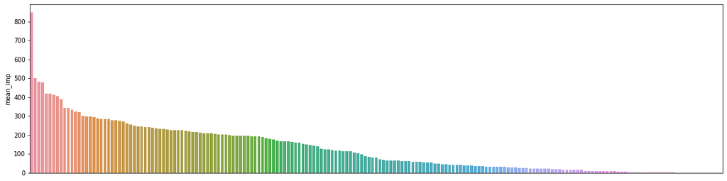

```python
df_feat_imp = pd.DataFrame(index=FEATURES)
df_feat_imp["imp0"] = feature_importances[0]
df_feat_imp["imp1"] = feature_importances[1]
df_feat_imp["imp2"] = feature_importances[2]
df_feat_imp["imp3"] = feature_importances[3]
df_feat_imp["imp4"] = feature_importances[4]
df_feat_imp["mean_imp"] = df_feat_imp.mean(axis=1).values

df_feat_imp = df_feat_imp.sort_values(by="mean_imp",ascending=False)

df_feat_imp.to_csv("feat_imp.csv")

fig, ax = plt.subplots(figsize=(20,5))
sns.barplot(x=df_feat_imp.index,y=df_feat_imp["mean_imp"])
plt.xticks([])
print(df_feat_imp)

#del df_feat_imp, feature_importances
#gc.collect()
```

### 08. 테스트 데이터 셋 확인 및 예측

목차로 이동하기

### 데이터 로드 및 RAM 사이즈 줄이기

```python
df_test = pd.read_parquet("/kaggle/input/amex-data-integer-dtypes-parquet-format/test.parquet")

print("convert float32 columns to float16")
for col in df_test[df_test.columns[df_test.dtypes=="float32"]]:
    df_test[col] = df_test[col].astype("float16")

print("date and time")
df_test["S_2"] = pd.to_datetime(df_test["S_2"])
df_test["days"] = (df_test["S_2"] - df_test.groupby(["customer_ID"])["S_2"].transform("min")).dt.days.astype("int16") + 1

print("grouping")
df_test = df_test.groupby(["customer_ID"]).tail(1).set_index('customer_ID')
```

```
convert float32 columns to float16
date and time
grouping
```

### 5개의 모델로 예측 후, 예측 내용에 대한 평균

```python
print("prediction")
pred=[]
for fold in range(5):
    print('FOLD:',fold)

    if len(pred)==0:
        pred = models[fold].predict_proba(df_test.drop(["S_2"],axis=1))[:,1]
    else:
        pred += models[fold].predict_proba(df_test.drop(["S_2"],axis=1))[:,1]


pred = pred/5
```

```
prediction
FOLD: 0
FOLD: 1
FOLD: 2
FOLD: 3
FOLD: 4
```

### 09. 제출

목차로 이동하기

```python
subm = pd.read_csv("/kaggle/input/amex-default-prediction/sample_submission.csv")
subm["prediction"] = pred
subm.to_csv("submission.csv", index=False)
```